# Praca Domowa 3

Paulina Przybyłek

8 listopada 2019

## Wybór wykresu

Wykres pochodzi ze strony https://viz.wtf/post/182504087404/it-boggles-my-mind-because-whatever-graph-software i przedstawia budżet ślubny. Aspektem wprowadzającym w błąd jest zła wysokość/długość słupków (np. 1 i 2 są prawie tej samej wysokości). Oszukuje to osobę, która ogląda wykres, zacierają się prawdziwe wartości.

Do sortowania nie mam uwag, bo jest to zamierzone, że ostatnia wartość mimo większej wartości od wcześniejszych znajduje się na końcu - są to dodatkowe koszty, więc ich umieszczenie po wyliczeniu innych kosztów z nazwy ma sens. Osobiście przeszkadza mi to, że napis nachodzi na jedną z kolumn - źle to wygląda.

[figure not shown]

## Wprowadzenie danych

Do wykresu nie było załączonych danych, więc wprowadzamy je ręcznie:

```r
#najpierw przepisujemy wartosci z wykresu, gdyz nie ma do nich danych
var <- c(39, 12, 9, 8, 8, 8, 3, 2, 2, 2, 1, 1, 1, 1, 1, 2)
#sum(var) #sumuje się do 100, czyli chociaż to jest dobrze
labels <- c("CATERING", "PHOTOGRAPHY & VIDEOGRAPHY", "CEREMONY & RECEPTION VENUE",
            "FLOVERS", "MUSIC (CEREMONY & RECEPTION)", "WEDDING DRESS",
            "INVITATIONS", "CAKE", "WEDDING RINGS", "WEDDING PLANNER",
            "TRANSPORTATION", "FAVORS & GIFTS", "OFFICIANT",
            "HAIR, MAKE UP & BEAUTY", "GROOM'S TUXEDO", "ADDL COSTS")
#tworzymy ramke danych i zmeinaimy typy zmiennych
data <- cbind(var, labels) %>% as.data.table()
data$var <- data$var %>% as.numeric()
#data <- data[order(var, decreasing = TRUE)]
#nadajemy tzw. levels, aby narysowac potem wykres w odpowiedniej kolejnosci
levels(data$labels) <- data$labels
```

## Wykres

- Poprawiona wysokość słupków
- Napisy są nad słupakami, aby żaden nie zachodził na niego (mogły być też zwykłymi podpisami na osiach, ale wtedy wykres był bardzo szeroki, co mi się nie podobało)
- Dodano oś i linie na wykresie, aby każdy mógł porównywać sobie daną wartość
- Wykorzystano kolory zgodnie z modą ślubną 2019 (biały, liliowy i lawendowy [lawenda jest przyciemniona, aby się nie zlał wykres])
- Zachowano sortowanie z orginalnego wykresu - niech koszty dodatkowe są ostatnie

Kod do wykresu:

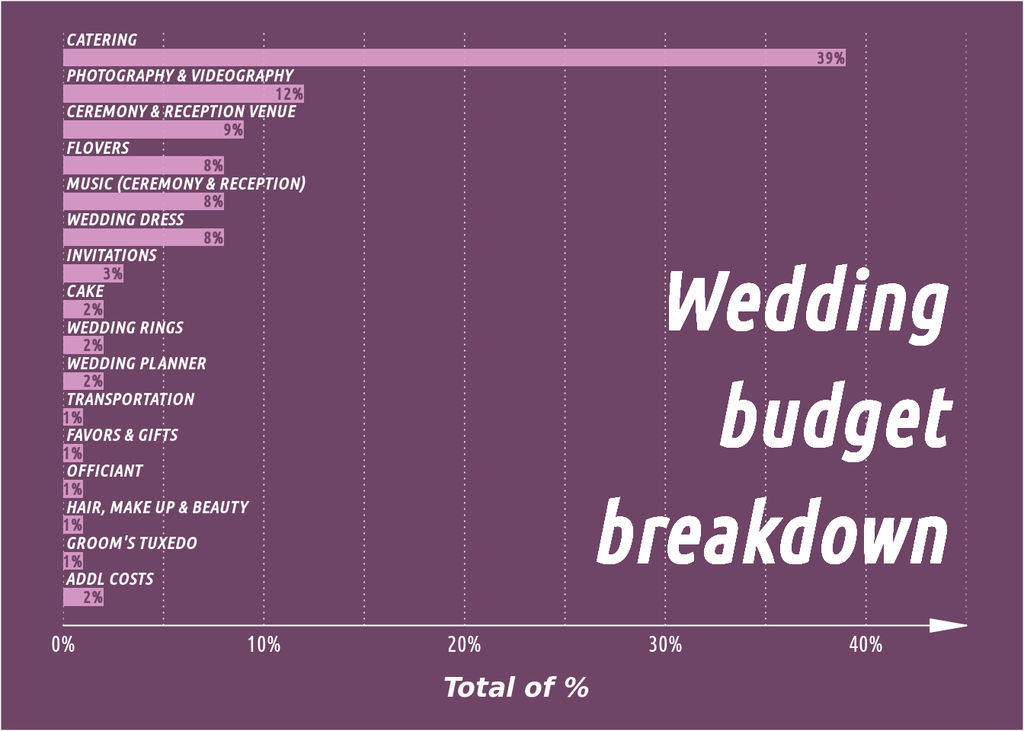

```r
ggplot(data,
       aes(x = factor(labels, rev(levels(data$labels))), y = var)) +
  #slupki z wartosciami
  geom_bar(stat = "identity",
           width = 0.5,
           alpha = 0.9,
           fill = "#dd9ecd") +
  #nazwy slupkow
  geom_text(y = 0.1,
            aes(label =  factor(labels, rev(levels(data$labels)))),
            size = 3,
            family = font[196],
            hjust = "left",
            nudge_x = 0.5,
            nudge_y = -1,
            fontface = "bold.italic",
            color = "white") +
  #odwrocenie wykresu
  coord_flip() +
  #tytuly
  labs(title = NULL,
       x = NULL,
       y = "Total of %") +
  #dopracowanie wykresu - linii, osi, tekstu, pola wykresu, marginesow
  theme(axis.ticks = element_blank(),
        panel.grid.major.y = element_blank(),
        panel.grid.major.x = element_line("#efebf9",
                                          size = 0.3,
                                          linetype = 3),
        panel.grid.minor.x = element_line("#efebf9",
                                          size = 0.3,
                                          linetype = 3),
        axis.text.y = element_blank(),
        plot.title = element_text(size = 30,
                                  face = "bold.italic",
                                  hjust = 0.9,
                                  family = font[196],
                                  color = "white"),
        plot.background = element_rect(fill =  "#6e4566"),
        panel.background = element_blank(),
        axis.line.x = element_line("white",
                                   arrow=arrow(angle=10, type = "closed")),
        axis.text.x = element_text(size = 11,
                                   family = font[196],
                                   color = "white"),
        axis.title.x.bottom = element_text(size = 13,
                                           face = "bold.italic",
                                           family = font[7],
                                           color = "white",
                                           margin = margin(t = 10, r = 0, b = 0, l = 0)),
        plot.margin = margin(0.5,1,0.5,1, "cm")) +
  #okreslenie wygladu osi y i x
  scale_y_continuous(expand = c(0,0),
                     limits = c(0, 45),
                     labels = paste0(seq(0, 40, 10), rep("%", 5))) +
  scale_x_discrete(expand = c(0.05, 0.05)) +
  #dodanie procentow do slupkow
  geom_text(aes(label = paste0(data$var, "%")),
            hjust = 1, family = font[196],
            size = 3,
            fontface = "bold",
            color = "#6e4566") +
  #umieszczenie tytulu na wykresie (wewnatrz pola)
    geom_text(aes(y = 44, x = "TRANSPORTATION",
                label = "Wedding\nbudget\nbreakdown"),
            colour = "white", hjust = "right", size = 14, fontface = "bold.italic",family = font[196])
```